# Customer Churn : Artificial Neural Networks

## Introduction

#### Dataset:

A telecommunications company is concerned about the number of customers leaving their landline business for cable competitors. They need to understand who is leaving.

**The data set includes information about-**

- Customers who left within the last month – the column is called Churn.
- Services that each customer has signed up for – phone, multiple lines, internet, online security, online backup, device protection, tech support, and streaming TV and movies.
- Customer account information – how long they’ve been a customer, contract, payment method, paperless billing, monthly charges, and total charges.
- Demographic info about customers – gender, age range, and if they have partners and dependents.
- Link to download dataset: **https://community.watsonanalytics.com/resources/**
- We have 7,042 observations and 21 columns.
- Dependent variable: **Churn**.

#### Libraries used:

1. pandas
2. numpy
3. matplotlib
4. seaborn
5. IPython
6. scikit-learn
7. keras

#### Backend used:

1. Tensorflow

#### Modules used:

1. warnings
2. from sklearn.preprocessing import LabelEncoder
3. from sklearn.pipeline import Pipeline
4. from imblearn.over_sampling import SMOTE
5. from sklearn.cross_validation import train_test_split
6. from sklearn.feature_selection import RFE
7. from sklearn.metrics import confusion_matrix
8. from sklearn.metrics import classification_report
9. from sklearn.metrics import roc_auc_score
10. from sklearn.metrics import roc_curve
11. from sklearn.model_selection import cross_val_score
12. from sklearn.linear_model import LogisticRegression
13. from keras.wrappers.scikit_learn import KerasClassifier
14. from sklearn.model_selection import GridSearchCV
15. from keras.models import Sequential
16. from keras.layers import Dense
17. from keras.layers import Dropout

#### Notebook Configuration:

**1. Create a new environment with Anaconda and Python:**

```
conda create -n tensorflow python=3.6 anaconda
```

**2. Activate the environment:**

```
activate tensorflow
```

**3. After this you can install TensorFlow and Keras:**

```
!pip install tensorflow
!pip install keras
```

**4. Update the packages:**

```
conda update --all
```

#### Models created:

1. Artificial Neural Network
2. Logistic Regression (for selection of features only)

#### Approach:

- Fetched dataset.
- Imported required libraries.
- Removed all the blank observations.
- Removed all the useless variables.
- Binned variable to reduce categorical levels.
- Label Encoded and One Hot Encoded variables.
- Scaled all the independent variables.
- Plotted heap map to see the correlation of the variables.
- Splitted dataset into training and test set in the ratio 80:20.
- Fitted ANN model on the training set.
- Checked behaviour of the model.
- Used Logistic Regression model for recursive feature elimination.
- Selected importance variables.
- Fitted ANN model on the training set containing important variables.
- Tuned ANN model.
- Checked the model performance using k(10)-fold-cross-validation.
- Predicted Churn for 2 new observations.

#### Total time on running the notebook:

- 10-11 hours on a standard PC having i7 processor and 8 GB of RAM.

##### What is the minimum number of observations to build ANN model?

##### No one can tell. Sometimes scikit-learn models are better in predictions and sometimes ANN beats them. Our dataset has around 7K observations, so we have created only 2 hidden layers.

### 1. Data Load

#### 1.1 Importing required libraries

```python
import warnings
import pandas as pd
import numpy as np
import seaborn as sns
import matplotlib.pyplot as plt
import keras
from keras.models import Sequential
from keras.layers import Dense
from keras.layers import Dropout
```

#### 1.2 Importing dataset

```python
dataset = pd.read_csv('E:\\ML\\Classification\\NN\\CustomerChurn.csv')
```

#### 1.3 Populating number of observations and variables

```python
dataset.shape
```

```
(7042, 21)
```

- We have 7,042 rows and 21 columns.

#### 1.4 Copying the instance of dataset into a new dataframe

```python
df = dataset
```

### 2. Data preprocessing

```python
df.head()
```

|  | customerID | gender | SeniorCitizen | Partner | Dependents | tenure | PhoneService | MultipleLines | InternetService | OnlineSecurity | ... | DeviceProtection | TechSupport | StreamingTV | StreamingMovies | Contract | PaperlessBilling | PaymentMethod | MonthlyCharges | TotalCharges | Churn |
| --- | --- | --- | --- | --- | --- | --- | --- | --- | --- | --- | --- | --- | --- | --- | --- | --- | --- | --- | --- | --- | --- |
| 0 | 7590-VHVEG | Female | 0.0 | Yes | No | 1.0 | No | No phone service | DSL | No | ... | No | No | No | No | Month-to-month | Yes | Electronic check | 29.85 | 29.85 | No |
| 1 | 5575-GNVDE | Male | 0.0 | No | No | 34.0 | Yes | No | DSL | Yes | ... | Yes | No | No | No | One year | No | Mailed check | 56.95 | 1889.50 | No |
| 2 | 3668-QPYBK | Male | 0.0 | No | No | 2.0 | Yes | No | DSL | Yes | ... | No | No | No | No | Month-to-month | Yes | Mailed check | 53.85 | 108.15 | Yes |
| 3 | 7795-CFOCW | Male | 0.0 | No | No | 45.0 | No | No phone service | DSL | Yes | ... | Yes | Yes | No | No | One year | No | Bank transfer (automatic) | 42.30 | 1840.75 | No |
| 4 | 9237-HQITU | Female | 0.0 | No | No | 2.0 | Yes | No | Fiber optic | No | ... | No | No | No | No | Month-to-month | Yes | Electronic check | 70.70 | 151.65 | Yes |

5 rows × 21 columns

#### 2.2 Checking data type of variables

```python
df.info()
```

```
<class 'pandas.core.frame.DataFrame'>
RangeIndex: 7042 entries, 0 to 7041
Data columns (total 21 columns):
customerID          7032 non-null object
gender              7032 non-null object
SeniorCitizen       7032 non-null float64
Partner             7032 non-null object
Dependents          7032 non-null object
tenure              7032 non-null float64
PhoneService        7032 non-null object
MultipleLines       7032 non-null object
InternetService     7032 non-null object
OnlineSecurity      7032 non-null object
OnlineBackup        7032 non-null object
DeviceProtection    7032 non-null object
TechSupport         7032 non-null object
StreamingTV         7032 non-null object
StreamingMovies     7032 non-null object
Contract            7032 non-null object
PaperlessBilling    7032 non-null object
PaymentMethod       7032 non-null object
MonthlyCharges      7032 non-null float64
TotalCharges        7032 non-null float64
Churn               7032 non-null object
dtypes: float64(4), object(17)
memory usage: 1.1+ MB
```

#### 2.3 Dropping column 'customerID'

- The column is useless, hence dropping it.

```python
df = df.drop(columns=['customerID'])
```

#### 2.4 Checking any missing values or observations

```python
df.isnull().values.any()
```

```
True
```

#### 2.5 Populating unique distribution of variables

```python
col = df.shape[1]
l=list(df.columns)
print ("Columns: ",col)
for i in range(col):
    d = df.iloc[:,i].unique()
    print ("\n",i,":", l[i],"\n")
    print ("\n",d)
```

```
Columns:  20

 0 : gender


 ['Female' 'Male' nan]

 1 : SeniorCitizen


 [ 0.  1. nan]

 2 : Partner


 ['Yes' 'No' nan]

 3 : Dependents


 ['No' 'Yes' nan]

 4 : tenure


 [ 1. 34.  2. 45.  8. 22. 10. 28. 62. 13. 16. 58. 49. 25. 69. 52. 71. 21.
 12. 30. 47. 72. 17. 27.  5. 46. 11. 70. 63. 43. 15. 60. 18. 66.  9.  3.
 31. 50. 64. 56.  7. 42. 35. 48. 29. 65. 38. 68. 32. 55. 37. 36. 41.  6.
  4. 33. 67. 23. 57. 61. 14. 20. 53. 40. 59. 24. 44. 19. 54. 51. 26. 39.
 nan]

 5 : PhoneService


 ['No' 'Yes' nan]

 6 : MultipleLines


 ['No phone service' 'No' 'Yes' nan]
```

[output cut: 51 more lines]

```

 17 : MonthlyCharges


 [29.85 56.95 53.85 ... 63.1  44.2  78.7 ]

 18 : TotalCharges


 [  29.85 1889.5   108.15 ...  346.45  306.6  6844.5 ]

 19 : Churn


 ['No' 'Yes' nan]
```

#### 2.6 Removing *nan* values

```python
df['gender'].replace('  ', np.nan, inplace=True)
df= df.dropna(subset=['gender'])
```

#### 2.7 Again populating unique distribution of variables to check if there are missing observations now

```python
col = df.shape[1]
l=list(df.columns)
print ("Columns: ",col)
for i in range(col):
    d = df.iloc[:,i].unique()
    print ("\n",i,":", l[i],"\n")
    print ("\n",d)
```

```
Columns:  20

 0 : gender


 ['Female' 'Male']

 1 : SeniorCitizen


 [0. 1.]

 2 : Partner


 ['Yes' 'No']

 3 : Dependents


 ['No' 'Yes']

 4 : tenure


 [ 1. 34.  2. 45.  8. 22. 10. 28. 62. 13. 16. 58. 49. 25. 69. 52. 71. 21.
 12. 30. 47. 72. 17. 27.  5. 46. 11. 70. 63. 43. 15. 60. 18. 66.  9.  3.
 31. 50. 64. 56.  7. 42. 35. 48. 29. 65. 38. 68. 32. 55. 37. 36. 41.  6.
  4. 33. 67. 23. 57. 61. 14. 20. 53. 40. 59. 24. 44. 19. 54. 51. 26. 39.]

 5 : PhoneService


 ['No' 'Yes']

 6 : MultipleLines


 ['No phone service' 'No' 'Yes']

```

[output cut: 50 more lines]

```

 17 : MonthlyCharges


 [29.85 56.95 53.85 ... 63.1  44.2  78.7 ]

 18 : TotalCharges


 [  29.85 1889.5   108.15 ...  346.45  306.6  6844.5 ]

 19 : Churn


 ['No' 'Yes']
```

- Now, all the missing observations are removed.

#### 2.8 Populating frequency of all the variables at observation level

```python
col = df.shape[1]
l=list(df.columns)
print ("Columns: ",col)
for i in range(col):
    d = df.groupby(df.iloc[:,i]).size()
    print ("\n",i,": ",l[i],"\n")
    print ("\n",d)
```

```
Columns:  20

 0 :  gender


 gender
Female    3483
Male      3549
dtype: int64

 1 :  SeniorCitizen


 SeniorCitizen
0.0    5890
1.0    1142
dtype: int64

 2 :  Partner


 Partner
No     3639
Yes    3393
dtype: int64

 3 :  Dependents


 Dependents
No     4933
Yes    2099
dtype: int64

 4 :  tenure


 tenure
1.0     613
2.0     238
```

[output cut: 294 more lines]

```
8547.15     1
8564.75     1
8594.40     1
8670.10     1
8672.45     1
8684.80     1
Length: 6530, dtype: int64

 19 :  Churn


 Churn
No     5163
Yes    1869
dtype: int64
```

#### 2.9 Encoding 'Churn' variable

```python
from sklearn.preprocessing import LabelEncoder

le = LabelEncoder()
df['Churn'] = le.fit_transform(df['Churn'])
```

#### 2.10 Reducing categorical levels

```python
df['MultipleLines'] = np.where(df['MultipleLines']=="No phone service","No",df['MultipleLines'])
df['OnlineSecurity'] = np.where(df['OnlineSecurity']=="No internet service","No",df['OnlineSecurity'])
df['OnlineBackup'] = np.where(df['OnlineBackup']=="No internet service","No",df['OnlineBackup'])
df['DeviceProtection'] = np.where(df['DeviceProtection']=="No internet service","No",df['DeviceProtection'])
df['TechSupport'] = np.where(df['TechSupport']=="No internet service","No",df['TechSupport'])
df['StreamingTV'] = np.where(df['StreamingTV']=="No internet service","No",df['StreamingTV'])
df['StreamingMovies'] = np.where(df['StreamingMovies']=="No internet service","No",df['StreamingMovies'])
```

#### 2.11 Descriptive statistics of numeric variables

```python
df.describe()
```

|  | SeniorCitizen | tenure | MonthlyCharges | TotalCharges | Churn |
| --- | --- | --- | --- | --- | --- |
| count | 7032.000000 | 7032.000000 | 7032.000000 | 7032.000000 | 7032.000000 |
| mean | 0.162400 | 32.421786 | 64.798208 | 2283.300441 | 0.265785 |
| std | 0.368844 | 24.545260 | 30.085974 | 2266.771362 | 0.441782 |
| min | 0.000000 | 1.000000 | 18.250000 | 18.800000 | 0.000000 |
| 25% | 0.000000 | 9.000000 | 35.587500 | 401.450000 | 0.000000 |
| 50% | 0.000000 | 29.000000 | 70.350000 | 1397.475000 | 0.000000 |
| 75% | 0.000000 | 55.000000 | 89.862500 | 3794.737500 | 1.000000 |
| max | 1.000000 | 72.000000 | 118.750000 | 8684.800000 | 1.000000 |

#### 2.12 Plotting frequency of dependent variable

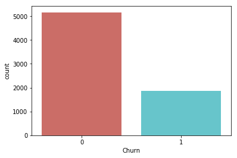

```
Percentage of No Churn (0) is 73 %.
Percentage of Churn (1) is 27 %.
```

```python
sns.countplot(x=df['Churn'],data=df,palette='hls')
plt.rcParams['figure.figsize'] = [6, 6]
warnings.simplefilter("ignore")
plt.show()

#Checking percentage distribution of dependent variable
count_no_sub = len(df[df['Churn']==0])
count_sub = len(df[df['Churn']==1])
pct_of_no_sub = count_no_sub/(count_no_sub+count_sub)
print("Percentage of No Churn (0) is %0.0f"%(pct_of_no_sub*100),"%.")
pct_of_sub = count_sub/(count_no_sub+count_sub)
print("Percentage of Churn (1) is %0.0f"%(pct_of_sub*100),"%.")
```

#### 2.13 Plotting frequency of Partner variable

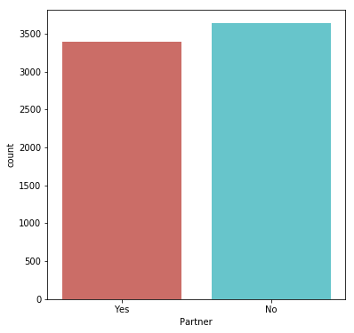

```
Percentage of No Partners is 48 %.
Percentage of Partners is 52 %.
```

```python
sns.countplot(x=df['Partner'],data=df,palette='hls')
plt.rcParams['figure.figsize'] = [6, 6]
warnings.simplefilter("ignore")
plt.show()

#Checking percentage distribution of dependent variable
count_no_sub = len(df[df['Partner']== 'Yes'])
count_sub = len(df[df['Partner']== 'No'])
pct_of_no_sub = count_no_sub/(count_no_sub+count_sub)
print("Percentage of No Partners is %0.0f"%(pct_of_no_sub*100),"%.")
pct_of_sub = count_sub/(count_no_sub+count_sub)
print("Percentage of Partners is %0.0f"%(pct_of_sub*100),"%.")
```

#### 2.14 Plotting frequency of dependent variable according to gender

```
Text(0,0.5,'Frequency of Churn')
```

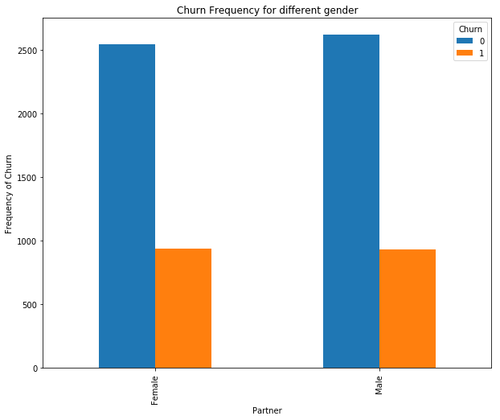

```python
%matplotlib inline
plt.rcParams['figure.figsize'] = [10, 8]
pd.crosstab(df.gender,df.Churn).plot(kind='bar')
plt.title('Churn Frequency for different gender')
plt.xlabel('Partner')
plt.ylabel('Frequency of Churn')
```

#### 2.15 Plotting frequency of dependent variable according to Partner

```
Text(0,0.5,'Frequency of Churn')
```

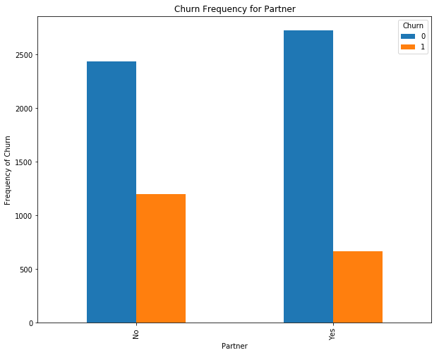

```python
%matplotlib inline
plt.rcParams['figure.figsize'] = [10, 8]
pd.crosstab(df.Partner,df.Churn).plot(kind='bar')
plt.title('Churn Frequency for Partner')
plt.xlabel('Partner')
plt.ylabel('Frequency of Churn')
```

#### 2.16 Label Encoding multiple columns

```python
from sklearn.preprocessing import LabelEncoder
from sklearn.pipeline import Pipeline

class MultiColumnLabelEncoder:
    def __init__(self,columns = None):
        self.columns = columns # array of column names to encode

    def fit(self,X,y=None):
        return self # not relevant here

    def transform(self,X):
        '''
        Transforms columns of X specified in self.columns using
        LabelEncoder(). If no columns specified, transforms all
        columns in X.
        '''
        output = X.copy()
        if self.columns is not None:
            for col in self.columns:
                output[col] = LabelEncoder().fit_transform(output[col])
        else:
            for colname,col in output.iteritems():
                output[colname] = LabelEncoder().fit_transform(col)
        return output

    def fit_transform(self,X,y=None):
        return self.fit(X,y).transform(X)

enc=MultiColumnLabelEncoder(columns = df.iloc[:,[0,1,2,3,5,6,8,9,10,11,12,13,15]]).fit_transform(df.astype(str))
```

#### 2.17 Appending encoded values into df

```python
enc['Churn'] = df['Churn']
df = enc
```

#### 2.18 Changing data type of variables

```python
df['tenure'] = df['tenure'].astype(float)
df['TotalCharges'] = df['TotalCharges'].astype(float)
df['MonthlyCharges'] = df['MonthlyCharges'].astype(float)
```

#### 2.19 Printing levels of categories in remaining categorical variables

```python
cat = df.select_dtypes(include=['object'])
col = cat.shape[1]
l=list(cat)
print ("Total number of categorical columns: ",col)
for i in range(col):
    d = cat.iloc[:,i].unique()
    print ("\n",l[i],"\n")
    print ("\n",d)
```

```
Total number of categorical columns:  3

 InternetService


 ['DSL' 'Fiber optic' 'No']

 Contract


 ['Month-to-month' 'One year' 'Two year']

 PaymentMethod


 ['Electronic check' 'Mailed check' 'Bank transfer (automatic)'
 'Credit card (automatic)']
```

#### 2.20 Dummifying the categorical variables

```python
df=pd.get_dummies(df, columns=["InternetService"])
```

```python
df = df.drop(columns=['InternetService_No'])
```

```python
df=pd.get_dummies(df, columns=["Contract"])
```

```python
df = df.drop(columns=['Contract_One year'])
```

```python
df=pd.get_dummies(df, columns=["PaymentMethod"])
```

```python
df = df.drop(columns=['PaymentMethod_Electronic check'])
```

#### 2.21 Printing list of all the variables

```python
list(df.columns)
```

```
['gender',
 'SeniorCitizen',
 'Partner',
 'Dependents',
 'tenure',
 'PhoneService',
 'MultipleLines',
 'OnlineSecurity',
 'OnlineBackup',
 'DeviceProtection',
 'TechSupport',
 'StreamingTV',
 'StreamingMovies',
 'PaperlessBilling',
 'MonthlyCharges',
 'TotalCharges',
 'Churn',
 'InternetService_DSL',
 'InternetService_Fiber optic',
 'Contract_Month-to-month',
 'Contract_Two year',
 'PaymentMethod_Bank transfer (automatic)',
 'PaymentMethod_Credit card (automatic)',
 'PaymentMethod_Mailed check']
```

#### 2.22 Moving dependent variable to the last of dataframe

```python
cols = list(df.columns)
cols.insert(len(list(df)), cols.pop(cols.index('Churn')))
df = df.loc[:, cols]
df.head()
```

|  | gender | SeniorCitizen | Partner | Dependents | tenure | PhoneService | MultipleLines | OnlineSecurity | OnlineBackup | DeviceProtection | ... | MonthlyCharges | TotalCharges | InternetService_DSL | InternetService_Fiber optic | Contract_Month-to-month | Contract_Two year | PaymentMethod_Bank transfer (automatic) | PaymentMethod_Credit card (automatic) | PaymentMethod_Mailed check | Churn |
| --- | --- | --- | --- | --- | --- | --- | --- | --- | --- | --- | --- | --- | --- | --- | --- | --- | --- | --- | --- | --- | --- |
| 0 | 0 | 0 | 1 | 0 | 1.0 | 0 | 0 | 0 | 1 | 0 | ... | 29.85 | 29.85 | 1 | 0 | 1 | 0 | 0 | 0 | 0 | 0 |
| 1 | 1 | 0 | 0 | 0 | 34.0 | 1 | 0 | 1 | 0 | 1 | ... | 56.95 | 1889.50 | 1 | 0 | 0 | 0 | 0 | 0 | 1 | 0 |
| 2 | 1 | 0 | 0 | 0 | 2.0 | 1 | 0 | 1 | 1 | 0 | ... | 53.85 | 108.15 | 1 | 0 | 1 | 0 | 0 | 0 | 1 | 1 |
| 3 | 1 | 0 | 0 | 0 | 45.0 | 0 | 0 | 1 | 0 | 1 | ... | 42.30 | 1840.75 | 1 | 0 | 0 | 0 | 1 | 0 | 0 | 0 |
| 4 | 0 | 0 | 0 | 0 | 2.0 | 1 | 0 | 0 | 0 | 0 | ... | 70.70 | 151.65 | 0 | 1 | 1 | 0 | 0 | 0 | 0 | 1 |

5 rows × 24 columns

#### 2.23 Plotting heat map

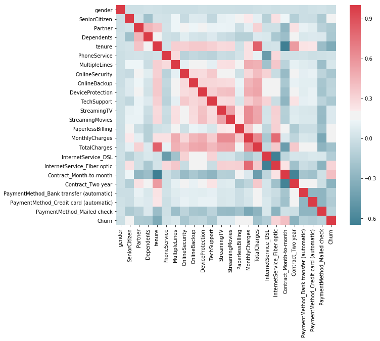

```python
import seaborn as sns
f, ax = plt.subplots(figsize=(10, 8))
corr = df.corr()
sns.heatmap(corr, mask=np.zeros_like(corr, dtype=np.bool), cmap=sns.diverging_palette(220, 10, as_cmap=True),
            square=True, ax=ax)
```

#### 2.24 Storing independent and dependent variables

```python
X = df.iloc[:, 0:23].values
y = df.iloc[:,[23]].values
```

#### 2.25 Splitting the dataset into the Training set and Test set in the ration 80:20.

##### Oversampling training set as dependent variable is imbalanced.

```python
from sklearn.model_selection import train_test_split

X_train, X_test, y_train, y_test = train_test_split(X, y, test_size = 0.2, random_state = 0)

#Oversampling
from imblearn.over_sampling import SMOTE
sm = SMOTE(random_state=12, ratio = 1.0)
X_train, y_train = sm.fit_sample(X_train, y_train)
```

#### 2.26 Printing number of observations in training and test set

```python
print("Number of observations and variables in training set: ",X_train.shape)
print("Number of observations and variables in test set: ",X_test.shape)
```

```
Number of observations and variables in training set:  (8250, 23)
Number of observations and variables in test set:  (1407, 23)
```

#### 2.27 Printing number of observations of dependent variable after oversampling

```python
print("Number of 0 in oversampled data",len(y_train == 0))
print("Number of 1 in oversampled data",len(y_train == 1))
```

```
Number of 0 in oversampled data 8250
Number of 1 in oversampled data 8250
```

#### 2.28 Feature Scaling train and test sets

```python
from sklearn.preprocessing import StandardScaler
sc = StandardScaler()
X_train = sc.fit_transform(X_train)
X_test = sc.transform(X_test)
```

### 3. Model Creation

#### Working of ANN algorithm

- **Step 1:** Randomly initialize the weights to small numbers close to 0 but not 0.
- **Step 2:** Input the first observation of the dataset in the input layer, each variable in one input node.
- **Step 3: Forward propagation-** From left to right, the neurons are activated in a way that the impact of each neuron's activation is limited by the weights. Propagate the activations until getting predicted value.
- **Step 4:** Compare the predicted result to the actual result. Measure the generated error (cost function).
- **Step 5: Back propagation-** From right to left, the error is back-propagated. Update the weights according to how much they are responsible for the error. The learning rate decided by how much the weights are being updated.
- **Step 6:** Repeat Steps 1 to 5 and update the weights after each observation (Reinforcement Learning; Gradient Descent) or Repeat Steps 1 to 5 and update the weights only after a batch of observations (Batch Learning; Stochastic Gradient Descent).

#### 3.1 Fitting ANN Classifier model

*Parameters overview:*

- **units:** Number of nodes to add in hidden layer.
- **kernel_initializer:** Initialize weights of layers. Default kernel is 'glorot_uniform'.
- **activation:** Activation function to be applied on Neuron. Using 'rectifier' function('relu') in Neuron and sigmoid function in output layer.
- **input_dim:** Number of nodes input layer.
- **optimizer:** Stochastic Gradient Descent algorithm to find optimum weights.
- **loss:** Same as sum of square of predicted minus actual observations. When dependent variable has 2 categorical levels, then use 'binary crossentropy'. If dependent variable has more than 2 categorical levels (multi-class), then use 'categorical_crossentropy'.
- **metrics:** What to improve in the model.
- **Dropout:** Fraction of input nodes to drop. To remove overfitting of data if there is.
- **batch_size:** The batch of observations to be passed at a time in input layer.
- **epoch:** When the whole training set passed through the ANN, that makes an epoch. Redo more epochs to get the lowest cost function.

*We have Added 2 hidden layers in the model*.

```python
# Initialising the ANN
classifier = Sequential()

# Adding the input layer and the first hidden layer
classifier.add(Dense(units = 12, kernel_initializer = 'uniform', activation = 'relu', input_dim = 23))
classifier.add(Dropout(p = 0.1))

# Adding the second hidden layer
classifier.add(Dense(units = 12, kernel_initializer = 'uniform', activation = 'relu'))
classifier.add(Dropout(p = 0.1))

# Adding the output layer
classifier.add(Dense(units = 1, kernel_initializer = 'uniform', activation = 'sigmoid'))

# Compiling the ANN
classifier.compile(optimizer = 'adam', loss = 'binary_crossentropy', metrics = ['accuracy'])

# Fitting the ANN to the Training set
acc_plot=classifier.fit(X_train, y_train, batch_size = 10, epochs = 100,verbose = 0,validation_data=(X_test,y_test))
```

#### 3.2 Function to plot Loss and Accuracy of training and test set

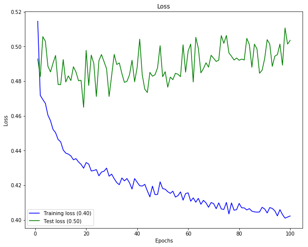

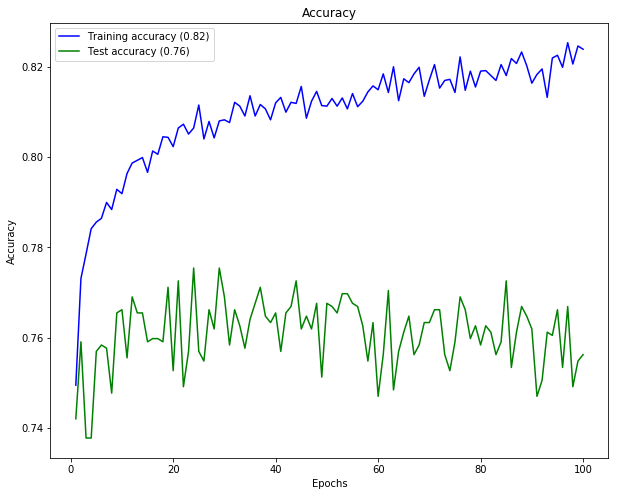

```python
def plot_history(history):
    loss_list = [s for s in history.history.keys() if 'loss' in s and 'val' not in s]
    val_loss_list = [s for s in history.history.keys() if 'loss' in s and 'val' in s]
    acc_list = [s for s in history.history.keys() if 'acc' in s and 'val' not in s]
    val_acc_list = [s for s in history.history.keys() if 'acc' in s and 'val' in s]

    if len(loss_list) == 0:
        print('Loss is missing in history')
        return

    ## As loss always exists
    epochs = range(1,len(history.history[loss_list[0]]) + 1)

    ## Loss
    plt.figure(1)
    for l in loss_list:
        plt.plot(epochs, history.history[l], 'b', label='Training loss (' + str(str(format(history.history[l][-1],'.2f'))+')'))
    for l in val_loss_list:
        plt.plot(epochs, history.history[l], 'g', label='Test loss (' + str(str(format(history.history[l][-1],'.2f'))+')'))

    plt.title('Loss')
    plt.xlabel('Epochs')
    plt.ylabel('Loss')
    plt.legend()

    ## Accuracy
    plt.figure(2)
    for l in acc_list:
        plt.plot(epochs, history.history[l], 'b', label='Training accuracy (' + str(format(history.history[l][-1],'.2f'))+')')
    for l in val_acc_list:
        plt.plot(epochs, history.history[l], 'g', label='Test accuracy (' + str(format(history.history[l][-1],'.2f'))+')')

    plt.title('Accuracy')
    plt.xlabel('Epochs')
    plt.ylabel('Accuracy')
    plt.legend()
    plt.show()

#Calling function
plot_history(acc_plot)
```

- Clearly, the model is overfitting the data as training loss is being decreased for training set and accuracy is being increase with increasing number of epochs.